# STS 112: Lab 10

James Chapman

In this lab, you will be using the variables you made in Notebook 10. Run that file and make sure that the final `couples` data frame is in your working environment. All graphs must be publication quality with accurate titles. Don’t forget to weight by `PERWT.x`.

```r
library(tidyverse)
library(viridis)
```

## Column graphs: Married and unmarried same- and different-sex couples

Make a column graph showing the **number** of married and unmarried same- and different-sex couples in 1990 and 2000. Put year on the x-axis, use fill color to indicate marital status, and facet by whether the couple is same- or different-sex.

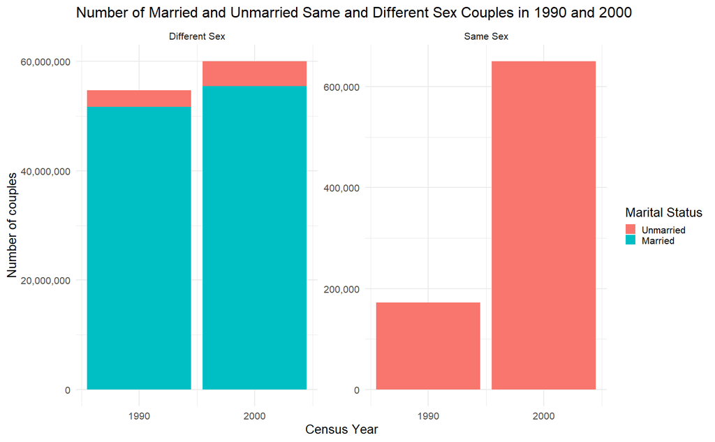

```r
couples %>% group_by(YEAR, MARRIED, SSEX) %>% count(wt = PERWT.x) %>%
  ggplot(aes(YEAR, n, fill = MARRIED)) +
  geom_col() +
  facet_wrap(vars(SSEX), scales = "free_y") +
  scale_x_continuous(breaks = c(1990, 2000)) +
  scale_y_continuous(labels = scales::comma) +
  theme_minimal(base_size = 20) +
  labs(x = "Census Year", y = "Number of couples", fill = "Marital Status", title = "Number of Married and Unmarried Same and Different Sex Couples in 1990 and 2000")
```

## Line graphs: Allocation

Now make a line graph for **unmarried couples only**, showing the percent that had their marital status allocated in 1990 and 2000. Use color to indicate whether the couple was same-sex or different-sex.

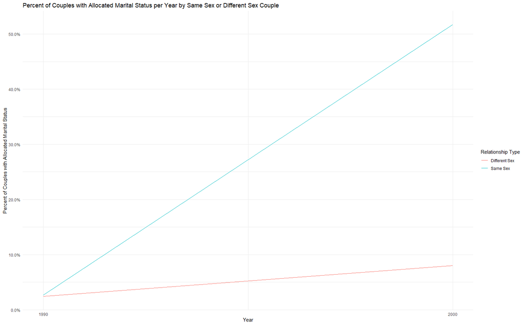

```r
couples %>% filter(MARRIED == "Unmarried") %>%
  group_by(YEAR, SSEX) %>% count(ALLOCATED, wt = PERWT.x) %>%
  mutate(TOTAL = sum(n), PCTALOC = n/TOTAL) %>% filter(ALLOCATED) %>%
  ggplot(aes(YEAR, PCTALOC, color = SSEX)) +
  geom_line() +
  theme_minimal() +
  scale_fill_brewer("Paired") +
  scale_y_continuous(labels = scales::percent) +
  scale_x_continuous(breaks = c(1990, 2000)) +
  labs(x = "Year", y = "Percent of Couples with Allocated Marital Status", title = "Percent of Couples with Allocated Marital Status per Year by Same Sex or Different Sex Couple", color = "Relationship Type")
```

## Population pyramids: Age and sex of person 1

**For 2000 only,** make population pyramids **for Person 1**, classified into four relationship types: different-sex married, different-sex unmarried, same-sex allocated, same-sex unallocated.

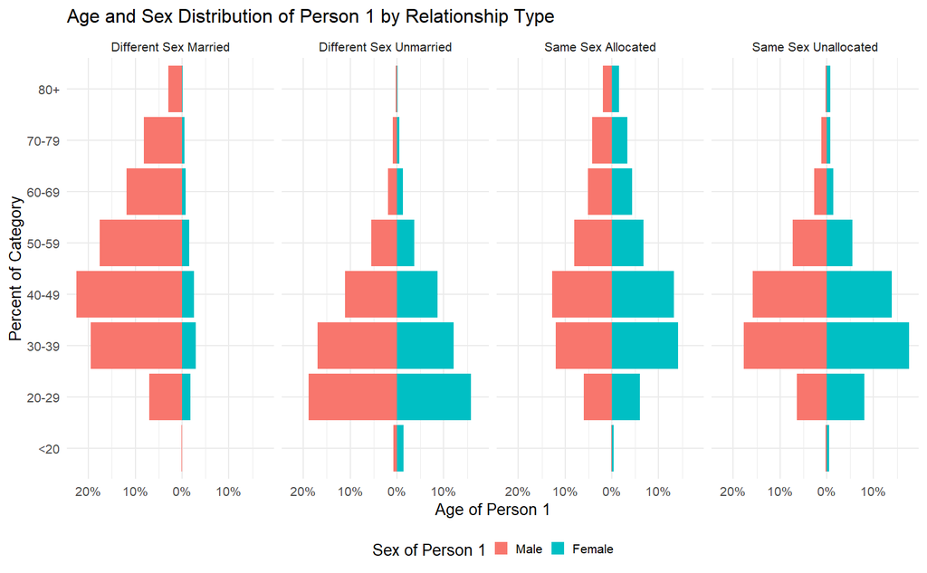

```r
couples %>% mutate(SEX.x = factor(SEX.x, labels = c("Male", "Female"))) %>% filter(YEAR == 2000) %>%
  group_by(TYPE) %>% count(AGECAT, SEX.x, wt = PERWT.x) %>%
  mutate(TOTAL = sum(n), n = ifelse(SEX.x == "Male", 0-n, n)) %>%
  ggplot(aes(AGECAT, n/TOTAL, fill = SEX.x)) +
  geom_col() +
  coord_flip() +
  #scale_fill_brewer(palette = "Set1") +
  scale_y_continuous(breaks = seq(-.2, .2, .1), labels = c("20%", "10%","0%", "10%","20%")) +
  theme_minimal(base_size = 20) +
  theme(legend.position = "bottom") +
  labs(x = "Percent of Category", y = "Age of Person 1", fill = "Sex of Person 1", title = "Age and Sex Distribution of Person 1 by Relationship Type") +
  facet_grid(cols = vars(TYPE))
```

## Box plots: Distribution of children among couples

**For 2000 only,* for each relationship type, make a box plot showing the distribution of children in the household (`NCHILD.x`). Use the tenth percentile for the bottom whisker and the ninetieth percentile for the top whisker.

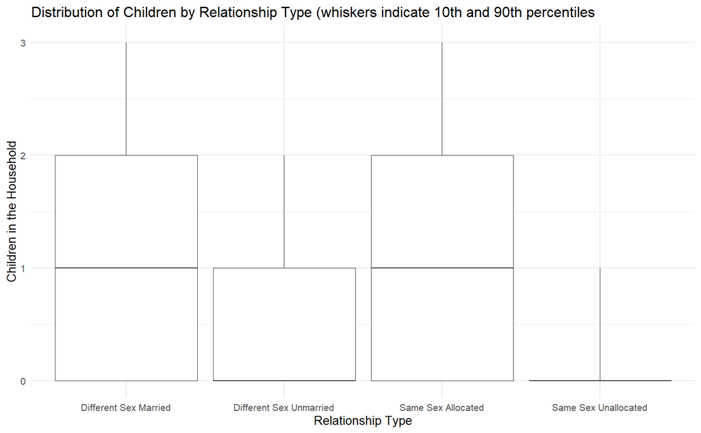

```r
couples %>% filter(YEAR == 2000) %>%
  group_by(TYPE) %>% summarize(MIN = quantile(rep(NCHILD.x, PERWT.x), .1),
                           LOW = quantile(rep(NCHILD.x, PERWT.x), .25),
                           MED = quantile(rep(NCHILD.x, PERWT.x), .50),
                           HIGH = quantile(rep(NCHILD.x, PERWT.x), .75),
                           MAX = quantile(rep(NCHILD.x, PERWT.x), .90)) %>%
  ggplot(aes(x = factor(TYPE))) +
         geom_boxplot(aes(ymin = MIN, lower = LOW, middle = MED, upper = HIGH, ymax = MAX), stat = "identity") +
         theme_minimal(base_size=20) +
         scale_fill_brewer(palette = "Paired") +
         labs(x = "Relationship Type", y = "Children in the Household", title = "Distribution of Children by Relationship Type (whiskers indicate 10th and 90th percentiles")
```

## Heat map: Primary language of Person 1

Make a heat map **for 2000 only**, showing relationship type on the x-axis and language of Person 1 on the y-axis, with color indicating the percentage of people in each relationship type (denominator) who primarily speak English or a different language (numerator). Columns should sum to 100%.

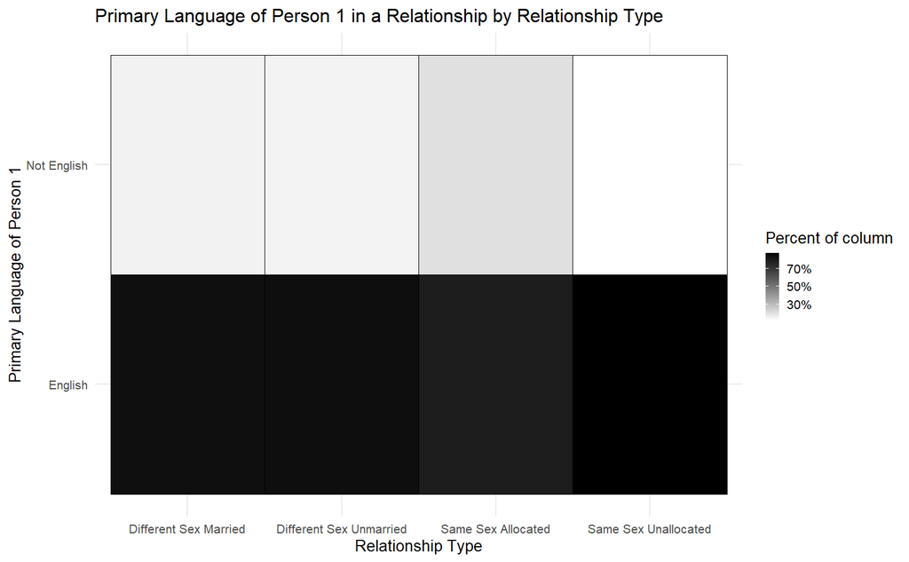

```r
#First heat map:
couples %>% filter(YEAR == 2000) %>%
  group_by(TYPE) %>% count(LANG, wt = PERWT.x) %>% mutate(TOTAL = sum(n)) %>%
  ggplot(aes(x = TYPE, y = LANG, fill = n/TOTAL)) + geom_tile(color = "black") +
  scale_fill_gradient(low = "White", high = "Black", labels = scales::percent) +
  theme_minimal(base_size = 20) +
  labs(x = "Relationship Type", y = "Primary Language of Person 1", fill = "Percent of column", title = "Primary Language of Person 1 in a Relationship by Relationship Type")
```